# Análisis Exploratorio de Datos de los Alquileres Vacacionales en Lisboa

#### 4.1.3 Distribución del tipo de vivienda y del número de huéspedes

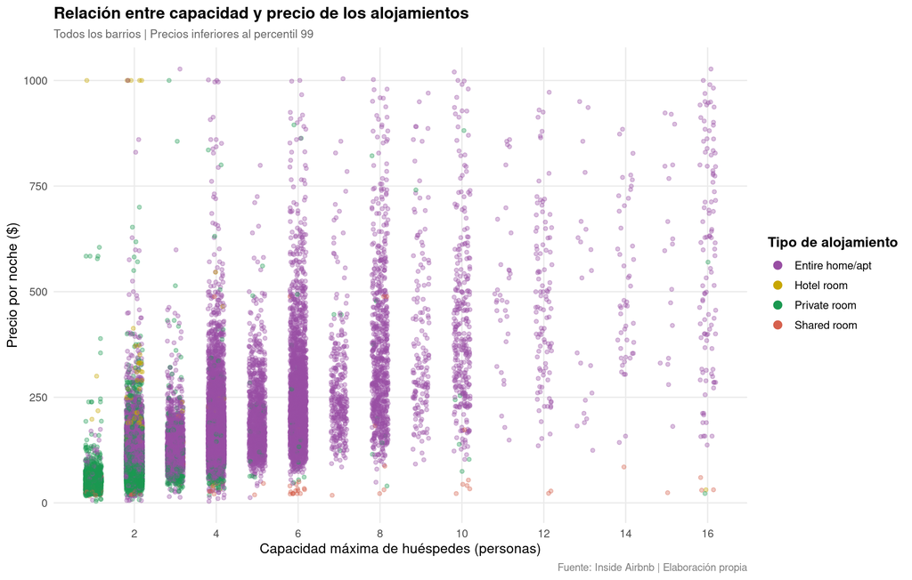

```r
# Prepare all neighbourhoods for a single scatterplot
capacity_price_data <- tidy_listings |>
  filter(
    !is.na(neighbourhood_cleansed),
    !is.na(accommodates),
    accommodates > 0,
    !is.na(room_type),
    !is.na(price),
    price > 0,
    price < price_p99
  )

room_colors <- c(
  "Entire home/apt" = "#984EA3",
  "Private room" = "#1A9850",
  "Shared room" = "#D6604D",
  "Hotel room" = "#C7A600"
)

ggplot(capacity_price_data, aes(
  x = accommodates,
  y = price,
  color = room_type
)) +
  geom_jitter(width = 0.2, height = 0, alpha = 0.35, size = 1.3) +
  scale_color_manual(values = room_colors, name = "Tipo de alojamiento") +
  scale_x_continuous(breaks = scales::breaks_pretty(n = 12)) +
  labs(
    title = "Relación entre capacidad y precio de los alojamientos",
    subtitle = "Todos los barrios | Precios inferiores al percentil 99",
    x = "Capacidad máxima de huéspedes (personas)",
    y = "Precio por noche ($)",
    caption = "Fuente: Inside Airbnb | Elaboración propia"
  ) +
  guides(color = guide_legend(override.aes = list(alpha = 1, size = 3))) +
  theme_minimal(base_size = 12) +
  theme(
    plot.title = element_text(face = "bold", size = 14),
    plot.subtitle = element_text(color = "gray40", size = 10),
    plot.caption = element_text(color = "gray50", size = 9),
    panel.grid.minor = element_blank(),
    legend.position = "right",
    legend.title = element_text(face = "bold")
  )
```

Ahora se verá si algún tipo de alquiler prevalece en los barrios de Lisboa

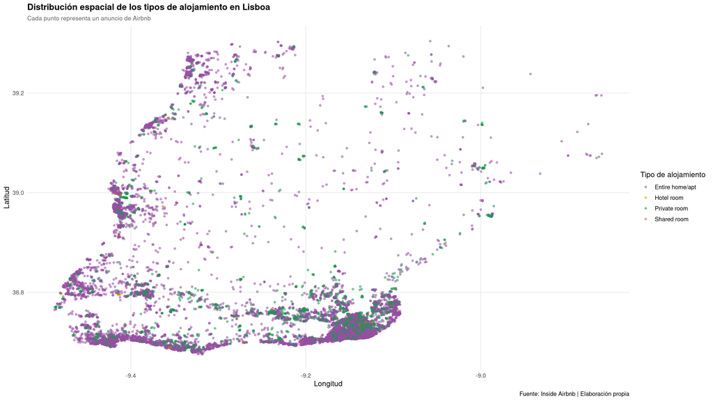

```r
room_colors <- c(
  "Entire home/apt" = "#984EA3",
  "Private room" = "#1A9850",
  "Shared room" = "#D6604D",
  "Hotel room" = "#C7A600"
)

p_data <- tidy_listings |>
  filter(
    !is.na(latitude),
    !is.na(longitude),
    !is.na(room_type)
  )

ggplot(p_data, aes(
  x = longitude,
  y = latitude,
  color = room_type
)) +
  geom_point(
    alpha = 0.5,
    size = 1.2
  ) +
  scale_color_manual(
    values = room_colors,
    name = "Tipo de alojamiento"
  ) +
  labs(
    title = "Distribución espacial de los tipos de alojamiento en Lisboa",
    subtitle = "Cada punto representa un anuncio de Airbnb",
    x = "Longitud",
    y = "Latitud",
    caption = "Fuente: Inside Airbnb | Elaboración propia"
  ) +
  theme_minimal(base_size = 12) +
  theme(
    plot.title = element_text(face = "bold", size = 14),
    plot.subtitle = element_text(color = "gray40", size = 10),
    panel.grid.minor = element_blank(),
    legend.position = "right"
  )
```

En vista de los resultados obtenidos, la oferta de alojamientos turísticos se concentra de forma desigual entre barrios. Entre las zonas de Lisboa que merecen especial atención destacan los barrios históricos de Santa Maria Maior y Misericórdia, que presentan una elevada cantidad de anuncios.

Asimismo, se observa una relación generalmente positiva entre la capacidad máxima de huéspedes y el precio por noche, especialmente en las viviendas completas, que predominan entre los alojamientos de mayor capacidad y precio.

### 4.2. ¿Qué grado de concentración presenta el mercado y qué proporción de los alojamientos está gestionada por grandes propietarios?

#### 4.2.1 Proporción de los alojamientos gestionada por grandes propietarios

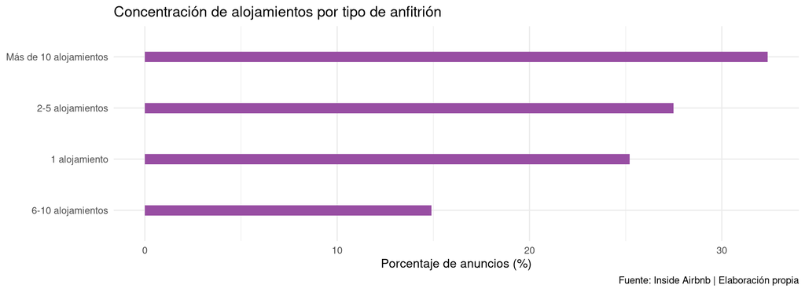

```r
host_data <- tidy_listings |>
  filter(!is.na(host_id)) |>
  count(host_id, name = "n_listings") |>
  mutate(
    host_category = case_when(
      n_listings == 1 ~ "1 alojamiento",
      n_listings <= 5 ~ "2-5 alojamientos",
      n_listings <= 10 ~ "6-10 alojamientos",
      TRUE ~ "Más de 10 alojamientos"
    )
  ) |>
  group_by(host_category) |>
  summarise(
    n_hosts = n(),
    total_listings = sum(n_listings),
    .groups = "drop"
  ) |>
  mutate(
    share_listings = 100 * total_listings / sum(total_listings)
  )

ggplot(host_data, aes(
  x = reorder(host_category, share_listings),
  y = share_listings
)) +
  geom_col(fill = "#984EA3", width = 0.2) +
  coord_flip() +
  labs(
    title = "Concentración de alojamientos por tipo de anfitrión",
    x = NULL,
    y = "Porcentaje de anuncios (%)",
    caption = "Fuente: Inside Airbnb | Elaboración propia"
  ) +
  theme_minimal(base_size = 12)
```

Es decir, sólo el 25% de la oferta es publicada por particulares con un único alojamiento, mientras que más del 30% está concentrada en grandes tenedores.

#### 4.2.2 Grado de concentración del mercado

Se hará a continuación un ranking con las entidades o personas con mayor cantidad de propiedades alquiladas.

```r
host_data <- tidy_listings |>
  filter(!is.na(host_id)) |>
  group_by(host_id, host_name) |>
  summarise(
    n_listings = n(),
    .groups = "drop"
  ) |>
  arrange(desc(n_listings)) |>
  slice_head(n = 100)

host_data
```

```
## # A tibble: 100 × 3
##      host_id host_name                       n_listings
##        <dbl> <chr>                                <int>
##  1   3953109 Feels Like Home                        284
##  2 505424337 Pedro                                  237
##  3 508522478 Smith&Adams Property Management        213
##  4 419162816 Ukio                                   206
##  5  76223539 BnBird Homes Lda                       197
##  6 683922126 Madalena                               159
##  7 186448151 Place To Stay (Ana)                    147
##  8   5691663 GestHomes By Alexandra & Pedro         117
##  9 331391493 Alojoeste                               92
## 10 265211529 Luís Miguel                             80
## # ℹ 90 more rows
```

Ahora se estudiará la presencia de estas entidades en los distintos barrios de Lisboa

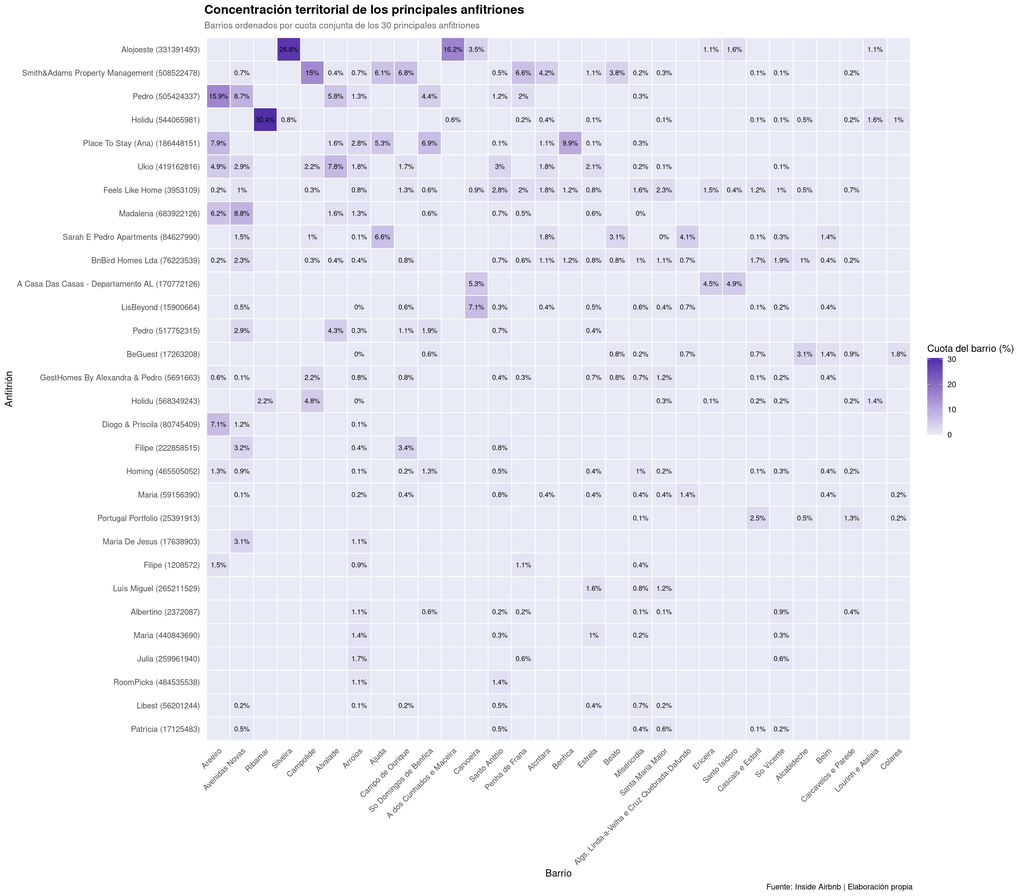

```r
# Prepare heatmap data
# Rank hosts by number of listings
host_data <- tidy_listings |>
  filter(!is.na(host_id)) |>
  count(host_id, name = "n_listings") |>
  arrange(desc(n_listings))

# Select top 30 hosts
top_hosts <- host_data |>
  slice_head(n = 30) |>
  pull(host_id)

# Select top 30 neighbourhoods
top_neighbourhoods <- tidy_listings |>
  filter(
    host_id %in% top_hosts,
    !is.na(neighbourhood_cleansed)
  ) |>
  count(neighbourhood_cleansed, sort = TRUE) |>
  slice_head(n = 30) |>
  pull(neighbourhood_cleansed)

# Prepare host labels
host_labels <- tidy_listings |>
  filter(host_id %in% top_hosts) |>
  group_by(host_id) |>
  summarise(
    host_name = first(host_name[!is.na(host_name)],
                      default = "Sin nombre"),
    .groups = "drop"
  ) |>
  mutate(
    host_label = paste0(host_name, " (", host_id, ")")
  )

# Total listings per neighbourhood (ALL hosts)
neighbourhood_totals <- tidy_listings |>
  filter(!is.na(neighbourhood_cleansed)) |>
  count(
    neighbourhood_cleansed,
    name = "total_neighbourhood"
  )

# Prepare heatmap data
heatmap_data <- tidy_listings |>
  filter(
    host_id %in% top_hosts,
    neighbourhood_cleansed %in% top_neighbourhoods
  ) |>
  count(
    host_id,
    neighbourhood_cleansed,
    name = "n_listings"
  ) |>
  tidyr::complete(
    host_id = top_hosts,
    neighbourhood_cleansed = top_neighbourhoods,
    fill = list(n_listings = 0)
  ) |>
  left_join(
    neighbourhood_totals,
    by = "neighbourhood_cleansed"
  ) |>
  mutate(
    percentage = 100 * n_listings / total_neighbourhood
  )

# Order neighbourhoods by cumulative percentage
neighbourhood_order <- heatmap_data |>
  group_by(neighbourhood_cleansed) |>
  summarise(
    cumulative_percentage = sum(percentage),
    .groups = "drop"
  ) |>
  arrange(desc(cumulative_percentage)) |>
  pull(neighbourhood_cleansed)

# Order hosts by sum of percentages
host_order <- heatmap_data |>
  group_by(host_id) |>
  summarise(
    cumulative_percentage = sum(percentage),
    .groups = "drop"
  ) |>
  arrange(desc(cumulative_percentage)) |>
  pull(host_id)

# Apply ordering
heatmap_data <- heatmap_data |>
  mutate(
    neighbourhood_cleansed = factor(
      neighbourhood_cleansed,
      levels = neighbourhood_order
    ),
    host_id = factor(
      as.character(host_id),
      levels = rev(as.character(host_order))
    )
  )

# Heatmap
ggplot(heatmap_data, aes(
  x = neighbourhood_cleansed,
  y = host_id,
  fill = percentage
)) +
  geom_tile(
    color = "white",
    linewidth = 0.4
  ) +
  geom_text(
    aes(label = if_else(
      n_listings > 0,
      paste0(round(percentage, 1), "%"),
      ""
    )),
    size = 2.7
  ) +
  scale_y_discrete(
    labels = setNames(
      host_labels$host_label,
      as.character(host_labels$host_id)
    )
  ) +
  scale_fill_gradient(
    low = "#E8EAF6",
    high = "#512DA8",
    name = "Cuota del barrio (%)"
  ) +
  labs(
    title = "Concentración territorial de los principales anfitriones",
    subtitle = "Barrios ordenados por cuota conjunta de los 30 principales anfitriones",
    x = "Barrio",
    y = "Anfitrión",
    caption = "Fuente: Inside Airbnb | Elaboración propia"
  ) +
  theme_minimal(base_size = 11) +
  theme(
    plot.title = element_text(face = "bold", size = 14),
    plot.subtitle = element_text(color = "gray40", size = 10),
    axis.text.x = element_text(angle = 45, hjust = 1),
    axis.text.y = element_text(size = 9),
    panel.grid = element_blank()
  )
```

El mapa de calor muestra que **la concentración de anuncios turísticos varía considerablemente entre anfitriones y barrios**. Se observa que algunos de los principales operadores, como *Feels Like Home*, *BnBird Homes* o *GuestHomes*, mantienen una presencia distribuida entre numerosos barrios, aunque sus cuotas individuales suelen ser relativamente reducidas. Esto indica una estrategia de gestión territorialmente diversificada, sin que necesariamente dominen el mercado de un barrio concreto.

### 4.3 ¿Cuál es la situación de las licencias turísticas de los alojamientos anunciados?

#### 4.3.1. Distribución de las licencias por barrio

Primero se averiguará el porcentaje total de viviendas con licencia que están anunciadas

```r
license_data <- tidy_listings |>
  mutate(
    has_license = !is.na(license) & str_trim(license) != ""
  ) |>
  count(has_license, name = "n_listings") |>
  mutate(
    percentage = round(100 * n_listings / sum(n_listings), 2)
  )

license_data
```

```
## # A tibble: 2 × 3
##   has_license n_listings percentage
##   <lgl>            <int>      <dbl>
## 1 FALSE             1042       4.19
## 2 TRUE             23834      95.8
```

Como se puede ver, casi el 96% de las ofertas son de viviendas con licencia. Ahora se verá la distribución de apartamentos sin licencia por barrio.

```r
neighbour_license <- tidy_listings |>
  group_by(neighbourhood_cleansed) |>
  summarise(
    total_listings = n(),
    no_license = sum(is.na(license) | str_trim(license) == ""),
    percentage = round(100 * no_license / total_listings, 2),
    .groups = "drop"
  ) |>
  arrange(desc(no_license))

neighbour_license
```

```
## # A tibble: 129 × 4
##    neighbourhood_cleansed                   total_listings no_license percentage
##    <chr>                                             <int>      <int>      <dbl>
##  1 Santa Maria Maior                                  3572        119       3.33
##  2 Misericrdia                                        2588        110       4.25
##  3 Arroios                                            2154         96       4.46
##  4 Cascais e Estoril                                  1629         88       5.4
##  5 Santo Antnio                                       1486         43       2.89
##  6 Colares                                             487         40       8.21
##  7 So Vicente                                         1250         38       3.04
##  8 S.Maria, S.Miguel, S.Martinho, S.Pedro …            655         35       5.34
##  9 Estrela                                             974         33       3.39
## 10 Ericeira                                            736         31       4.21
## # ℹ 119 more rows
```

#### 4.3.2. Relación entre las viviendas sin licencia turística y su precio.

Ahora se estudiará la relación entre la licencia y el precio medio del alojamiento

```r
# Calculate price statistics by license status
license_price <- tidy_listings |>
  filter(
    !is.na(price),
    price > 0,
    price < price_p99
  ) |>
  mutate(
    license_status = if_else(
      !is.na(license) & str_trim(license) != "",
      "Con licencia declarada",
      "Sin licencia declarada"
    )
  ) |>
  group_by(license_status) |>
  summarise(
    n_listings = n(),
    mean_price = mean(price),
    median_price = median(price),
    .groups = "drop"
  )

license_price
```

```
## # A tibble: 2 × 4
##   license_status         n_listings mean_price median_price
##   <chr>                       <int>      <dbl>        <dbl>
## 1 Con licencia declarada      21553       167.         135.
## 2 Sin licencia declarada        856       166.         137
```

Del análisis puede observarse que los distritos con mayor oferta son asimismo los que mayor cantidad de viviendas sin licencia ofertan. Esto es un problema ya que la cantidad de viviendas con licencia se regula para limitar la cantidad de alquiler vacacional en cada barrio a como máximo el 10% de la vivienda en total. Un valor menor al real camufla alquileres vacacionales como residenciales y presiona al sector inmobiliario de larga duración.

También puede verse que el precio no parece verse influenciado por que el alojamiento tenga licencia o no ya que viene a ser idénticos para ambos casos.